# HNB DigiMedia Map 6: Source Concentration and Market Structure

Analyzing Attention Market Concentration and Gatekeeper Vulnerability

Author

HNB DigiMedia Project

Published

January 28, 2026

# 1 Introduction

This document presents **Map 6: Source Concentration and Market Structure Analysis** of the HNB DigiMedia project. The core question driving this analysis is:

> **How concentrated is the attention market for HNB coverage, and does this concentration create systemic vulnerabilities for monetary policy communication?**

## 1.1 Theoretical Motivation

The literature establishes that monetary policy works primarily through managing expectations (Woodford 2001). If a handful of media sources dominate public attention on central bank matters, then:

1. **Gatekeeper dependency:** HNB communication effectiveness depends critically on how these gatekeepers frame content
2. **Fragility risk:** Changes in gatekeeper behavior (editorial shifts, ownership changes, platform decline) could disrupt communication channels
3. **Message distortion:** Concentrated intermediation increases opportunities for framing divergence from official messaging

Morris and Shin (2002) showed that public information can crowd out private information when it receives “too much weight.” In a concentrated attention market, dominant sources become de facto public signals that may override diverse interpretations.

## 1.2 Market Structure Framework

We apply industrial organization concepts to the attention market:

| Metric | Definition | Interpretation |
| --- | --- | --- |
| Gini Coefficient | Inequality measure (0-1) | Higher = more concentrated |
| HHI | Sum of squared market shares | >2500 = highly concentrated |
| CR4 / CR10 | Top 4/10 concentration ratio | Share of top sources |
| Power Law α | Zipf distribution exponent | Steeper = more inequality |

```r
hnb <- readRDS("C:/Users/lsikic/Dropbox/hnb.rds")
setDT(hnb)

hnb[, date := as.Date(DATE)]
hnb[, year := year(date)]
hnb[, month := month(date)]

hnb[, period := fcase(
  date < as.Date("2023-01-01"), "ERM II",
  default = "Euro Era"
)]
hnb[, period := factor(period, levels = c("ERM II", "Euro Era"))]

n_articles <- nrow(hnb)
n_sources <- uniqueN(hnb$FROM)
total_reach <- sum(hnb$REACH, na.rm = TRUE)

cat("Data loaded:", n_articles, "articles from", n_sources, "sources\n")
```

```
Data loaded: 19128 articles from 894 sources
```

```r
# =============================================================================
# ACTOR CLASSIFICATION - SYNCHRONIZED WITH MAPS 1-5
# =============================================================================

manual_overrides <- list(
  "HNB Official" = c(
    "hnb.hr", "hrvatska narodna banka",
    "hrvatska narodna banka / croatian national bank"
  ),
  "Financial Regulators" = c(
    "hanfa.hr", "hanfa", "hrvatska agencija za nadzor financijskih usluga",
    "fina.hr", "fina", "financijska agencija"
  ),
  "Government" = c(
    "gov.hr", "vlada", "vlada republike hrvatske",
    "ministarstvo financija", "sabor.hr"
  ),
  "Financial Media" = c(
    "poslovni.hr", "poslovni dnevnik", "seebiz.eu", "seebiz",
    "lider.media", "lidermedia.hr", "lider", "bloombergadria.com",
    "bloomberg adria", "hrportfolio.hr", "privredni.hr"
  ),
  "Commercial Banks" = c(
    "zaba.hr", "zagrebačka banka", "pbz.hr", "privredna banka zagreb",
    "erste.hr", "erste banka", "hpb.hr", "hrvatska poštanska banka",
    "otp banka", "raiffeisen", "addiko"
  ),
  "Academic/Expert" = c(
    "eizg.hr", "ekonomski institut zagreb", "ijf.hr",
    "institut za javne financije", "ekonomski fakultet"
  )
)

general_media_sources <- c(
  "index.hr", "index", "jutarnji.hr", "jutarnji", "jutarnji list",
  "vecernji.hr", "vecernji", "večernji list",
  "24sata.hr", "24sata", "slobodnadalmacija.hr", "slobodna dalmacija",
  "novilist.hr", "novi list", "dnevnik.hr", "dnevnik",
  "tportal.hr", "tportal", "telegram.hr", "telegram",
  "net.hr", "rtl.hr", "rtl", "hrt.hr", "hrt",
  "n1info.hr", "n1info.com", "n1", "nacional.hr", "nacional",
  "direktno.hr", "direktno", "dnevno.hr", "dnevno"
)

classify_actor_hnb <- function(from_val, url_val = NA) {
  from_lower <- tolower(trimws(as.character(from_val)))
  url_lower <- tolower(ifelse(is.na(url_val), "", as.character(url_val)))
  combined <- paste(from_lower, url_lower)

  match_any <- function(patterns, text, fixed = TRUE) {
    any(sapply(patterns, function(p) grepl(p, text, fixed = fixed)))
  }

  for (actor_type in names(manual_overrides)) {
    if (match_any(manual_overrides[[actor_type]], from_lower)) {
      return(actor_type)
    }
  }

  if (grepl("hnb\\.hr", url_lower) || grepl("hnb\\.hr", from_lower)) {
    return("HNB Official")
  }

  if (grepl("hanfa|fina\\.hr", combined)) {
    return("Financial Regulators")
  }

  if (grepl("gov\\.hr|vlada|ministarstvo", combined)) {
    return("Government")
  }

  bank_patterns <- c("banka", "bank", "zaba", "pbz", "erste", "hpb",
                     "otp", "raiffeisen", "addiko", "sberbank")
  if (match_any(bank_patterns, from_lower)) {
    if (!grepl("narodna|hnb|central", from_lower)) {
      return("Commercial Banks")
    }
  }

  financial_media_patterns <- c(
    "poslovni", "seebiz", "lider", "bloomberg", "portfolio",
    "privredni", "finance", "ekonom", "business", "capital"
  )
  if (match_any(financial_media_patterns, from_lower)) {
    return("Financial Media")
  }

  if (match_any(general_media_sources, from_lower)) {
    return("General Media")
  }

  news_patterns <- c("portal", "vijesti", "news", "info", "dnevni",
                     "radio", "tv", ".hr")
  if (match_any(news_patterns, from_lower)) {
    return("General Media")
  }

  return("Other")
}

hnb[, ACTOR_TYPE := mapply(classify_actor_hnb, FROM, URL)]
hnb[, INSTITUTIONAL := ACTOR_TYPE %in% c("HNB Official", "Financial Regulators", "Government")]
```

# 2 Analysis 6.1: Overall Market Concentration

## 2.1 Source-Level Market Shares

```r
source_stats <- hnb[, .(
  Articles = .N,
  Total_REACH = sum(REACH, na.rm = TRUE),
  Mean_REACH = mean(REACH, na.rm = TRUE),
  ACTOR_TYPE = first(ACTOR_TYPE),
  Institutional = first(INSTITUTIONAL)
), by = FROM][order(-Total_REACH)]

source_stats[, `:=`(
  Article_Share = Articles / sum(Articles) * 100,
  REACH_Share = Total_REACH / sum(Total_REACH) * 100,
  Rank = .I
)]

source_stats[, Cumulative_REACH_Share := cumsum(REACH_Share)]
source_stats[, Cumulative_Article_Share := cumsum(Article_Share)]
```

## 2.2 Concentration Metrics Summary

```r
# Gini coefficients
gini_reach <- ineq(source_stats$Total_REACH, type = "Gini")
gini_articles <- ineq(source_stats$Articles, type = "Gini")

# HHI (Herfindahl-Hirschman Index) - using percentage shares squared, summed
hhi_reach <- sum((source_stats$REACH_Share)^2)
hhi_articles <- sum((source_stats$Article_Share)^2)

# Concentration ratios
cr1_reach <- source_stats[1, REACH_Share]
cr4_reach <- sum(source_stats[1:min(4, nrow(source_stats)), REACH_Share])
cr10_reach <- sum(source_stats[1:min(10, nrow(source_stats)), REACH_Share])
cr20_reach <- sum(source_stats[1:min(20, nrow(source_stats)), REACH_Share])

cr1_articles <- source_stats[1, Article_Share]
cr4_articles <- sum(source_stats[1:min(4, nrow(source_stats)), Article_Share])
cr10_articles <- sum(source_stats[1:min(10, nrow(source_stats)), Article_Share])
cr20_articles <- sum(source_stats[1:min(20, nrow(source_stats)), Article_Share])

# HHI classification
hhi_class <- case_when(
  hhi_reach < 1500 ~ "Unconcentrated",
  hhi_reach < 2500 ~ "Moderately Concentrated",
  TRUE ~ "Highly Concentrated"
)

tibble(
  Metric = c(
    "Number of Sources",
    "Gini Coefficient (REACH)",
    "Gini Coefficient (Articles)",
    "HHI (REACH)",
    "HHI (Articles)",
    "HHI Classification",
    "CR1 (Top Source REACH Share)",
    "CR4 (Top 4 REACH Share)",
    "CR10 (Top 10 REACH Share)",
    "CR20 (Top 20 REACH Share)"
  ),
  Value = c(
    format(n_sources, big.mark = ","),
    sprintf("%.3f", gini_reach),
    sprintf("%.3f", gini_articles),
    sprintf("%.0f", hhi_reach),
    sprintf("%.0f", hhi_articles),
    hhi_class,
    sprintf("%.1f%%", cr1_reach),
    sprintf("%.1f%%", cr4_reach),
    sprintf("%.1f%%", cr10_reach),
    sprintf("%.1f%%", cr20_reach)
  ),
  Interpretation = c(
    "Total unique publishers in corpus",
    "0 = perfect equality, 1 = perfect inequality",
    "0 = perfect equality, 1 = perfect inequality",
    "<1500 unconcentrated, >2500 highly concentrated",
    "<1500 unconcentrated, >2500 highly concentrated",
    "Based on DOJ/FTC market concentration guidelines",
    "Single source dominance",
    "Oligopoly threshold (>60% = tight oligopoly)",
    "Extended market concentration",
    "Broad market concentration"
  )
) %>%
  kable(col.names = c("Metric", "Value", "Interpretation")) %>%
  kable_styling(bootstrap_options = c("striped", "hover"), full_width = FALSE)
```

| Metric | Value | Interpretation |
| --- | --- | --- |
| Number of Sources | 894 | Total unique publishers in corpus |
| Gini Coefficient (REACH) | 0.953 | 0 = perfect equality, 1 = perfect inequality |
| Gini Coefficient (Articles) | 0.843 | 0 = perfect equality, 1 = perfect inequality |
| HHI (REACH) | 572 | <1500 unconcentrated, >2500 highly concentrated |
| HHI (Articles) | 135 | <1500 unconcentrated, >2500 highly concentrated |
| HHI Classification | Unconcentrated | Based on DOJ/FTC market concentration guidelines |
| CR1 (Top Source REACH Share) | 17.3% | Single source dominance |
| CR4 (Top 4 REACH Share) | 38.0% | Oligopoly threshold (>60% = tight oligopoly) |
| CR10 (Top 10 REACH Share) | 60.7% | Extended market concentration |
| CR20 (Top 20 REACH Share) | 78.4% | Broad market concentration |

## 2.3 Lorenz Curve: REACH Inequality

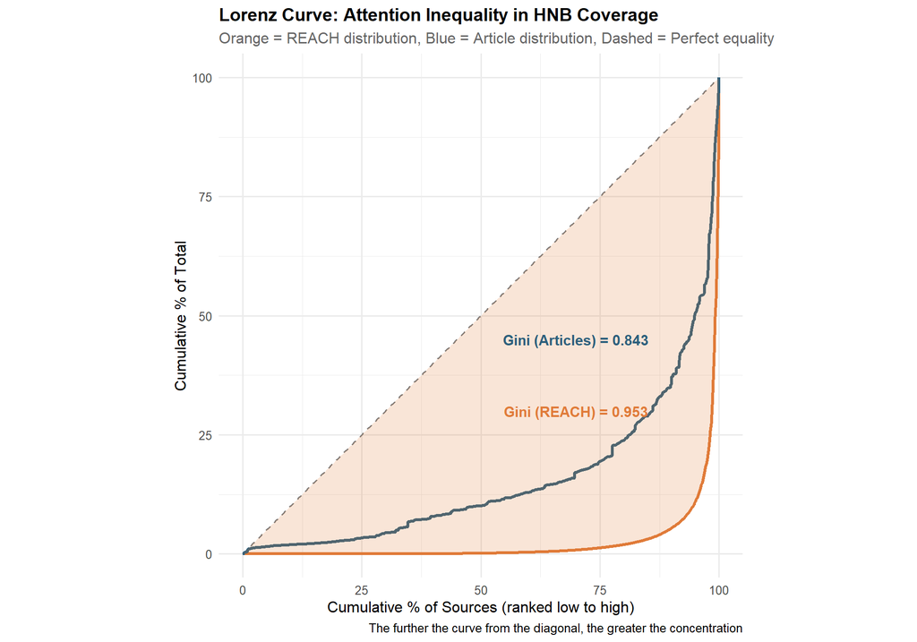

```r
# Create Lorenz curve data
lorenz_data <- source_stats[order(Total_REACH), .(
  FROM, Total_REACH, Articles
)]
lorenz_data[, `:=`(
  cum_sources = .I / .N * 100,
  cum_reach = cumsum(Total_REACH) / sum(Total_REACH) * 100,
  cum_articles = cumsum(Articles) / sum(Articles) * 100
)]

# Add origin point
lorenz_plot <- rbind(
  data.table(cum_sources = 0, cum_reach = 0, cum_articles = 0),
  lorenz_data[, .(cum_sources, cum_reach, cum_articles)]
)

ggplot(lorenz_plot) +
  geom_line(aes(x = cum_sources, y = cum_sources),
            linetype = "dashed", color = "gray50") +
  geom_line(aes(x = cum_sources, y = cum_reach),
            color = "#e07b39", linewidth = 1.2) +
  geom_line(aes(x = cum_sources, y = cum_articles),
            color = "#2c5f7c", linewidth = 1.2) +
  geom_ribbon(aes(x = cum_sources, ymin = cum_reach, ymax = cum_sources),
              fill = "#e07b39", alpha = 0.2) +
  annotate("text", x = 70, y = 30,
           label = paste0("Gini (REACH) = ", sprintf("%.3f", gini_reach)),
           color = "#e07b39", fontface = "bold", size = 4) +
  annotate("text", x = 70, y = 45,
           label = paste0("Gini (Articles) = ", sprintf("%.3f", gini_articles)),
           color = "#2c5f7c", fontface = "bold", size = 4) +
  labs(
    title = "Lorenz Curve: Attention Inequality in HNB Coverage",
    subtitle = "Orange = REACH distribution, Blue = Article distribution, Dashed = Perfect equality",
    x = "Cumulative % of Sources (ranked low to high)",
    y = "Cumulative % of Total",
    caption = "The further the curve from the diagonal, the greater the concentration"
  ) +
  coord_equal() +
  scale_x_continuous(limits = c(0, 100)) +
  scale_y_continuous(limits = c(0, 100))
```

## 2.4 Cumulative Distribution

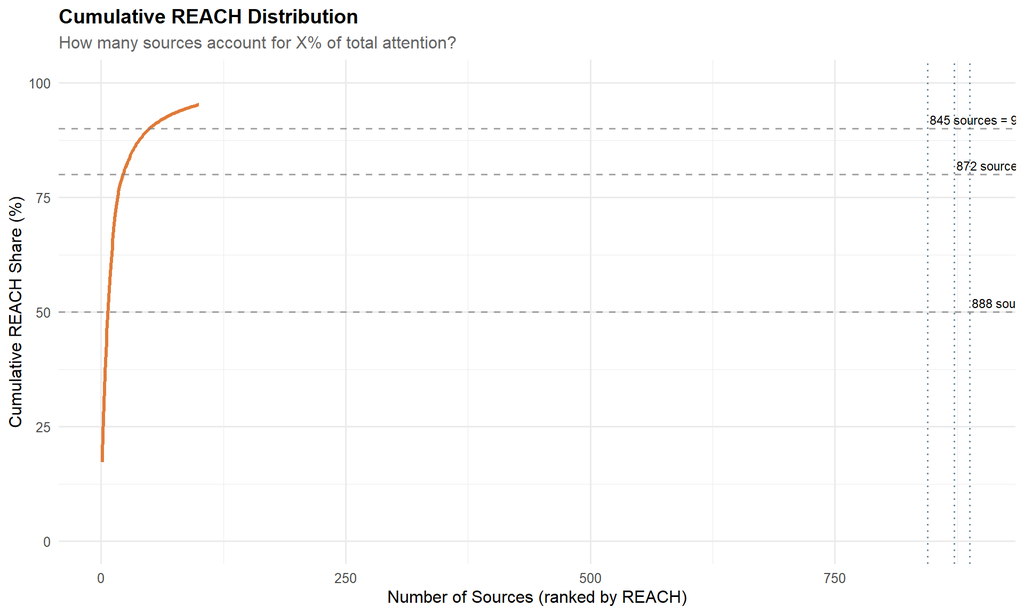

```r
# How many sources needed for X% of REACH
reach_50 <- source_stats[Cumulative_REACH_Share >= 50, .N][1]
reach_80 <- source_stats[Cumulative_REACH_Share >= 80, .N][1]
reach_90 <- source_stats[Cumulative_REACH_Share >= 90, .N][1]

ggplot(source_stats[1:min(100, nrow(source_stats))],
       aes(x = Rank, y = Cumulative_REACH_Share)) +
  geom_line(color = "#e07b39", linewidth = 1.2) +
  geom_hline(yintercept = c(50, 80, 90), linetype = "dashed", color = "gray50", alpha = 0.7) +
  geom_vline(xintercept = c(reach_50, reach_80, reach_90),
             linetype = "dotted", color = "#2c5f7c", alpha = 0.7) +
  annotate("text", x = reach_50 + 2, y = 52,
           label = paste0(reach_50, " sources = 50%"), hjust = 0, size = 3) +
  annotate("text", x = reach_80 + 2, y = 82,
           label = paste0(reach_80, " sources = 80%"), hjust = 0, size = 3) +
  annotate("text", x = reach_90 + 2, y = 92,
           label = paste0(reach_90, " sources = 90%"), hjust = 0, size = 3) +
  scale_y_continuous(limits = c(0, 100)) +
  labs(
    title = "Cumulative REACH Distribution",
    subtitle = "How many sources account for X% of total attention?",
    x = "Number of Sources (ranked by REACH)",
    y = "Cumulative REACH Share (%)"
  )
```

# 3 Analysis 6.2: Attention Gatekeepers

## 3.1 Top 20 Sources by REACH

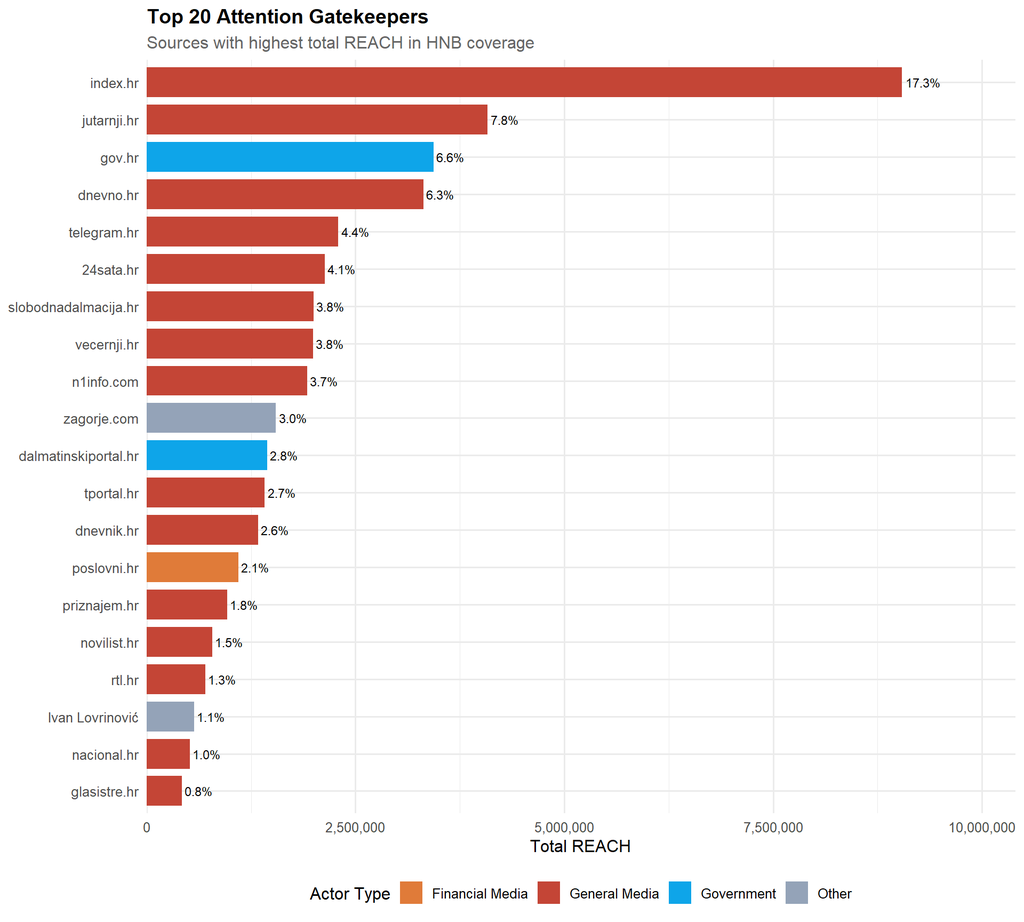

```r
top20 <- source_stats[1:20]

ggplot(top20, aes(x = reorder(FROM, Total_REACH), y = Total_REACH, fill = ACTOR_TYPE)) +
  geom_col(width = 0.8) +
  geom_text(aes(label = sprintf("%.1f%%", REACH_Share)), hjust = -0.1, size = 3) +
  coord_flip() +
  scale_fill_manual(values = actor_colors) +
  scale_y_continuous(labels = comma, expand = expansion(mult = c(0, 0.15))) +
  labs(
    title = "Top 20 Attention Gatekeepers",
    subtitle = "Sources with highest total REACH in HNB coverage",
    x = NULL,
    y = "Total REACH",
    fill = "Actor Type"
  )
```

## 3.2 Gatekeeper Profile Table

```r
top20 %>%
  mutate(
    Articles = format(Articles, big.mark = ","),
    Total_REACH = format(Total_REACH, big.mark = ","),
    Mean_REACH = format(round(Mean_REACH, 0), big.mark = ","),
    Article_Share = sprintf("%.2f%%", Article_Share),
    REACH_Share = sprintf("%.2f%%", REACH_Share),
    Cumulative_REACH_Share = sprintf("%.1f%%", Cumulative_REACH_Share),
    Institutional = ifelse(Institutional, "Yes", "No")
  ) %>%
  select(Rank, FROM, ACTOR_TYPE, Institutional, Articles, Article_Share,
         REACH_Share, Cumulative_REACH_Share, Mean_REACH) %>%
  kable(col.names = c("Rank", "Source", "Actor Type", "Inst.", "Articles",
                      "Article %", "REACH %", "Cumul. %", "Mean REACH")) %>%
  kable_styling(bootstrap_options = c("striped", "hover"), full_width = FALSE) %>%
  scroll_box(height = "500px")
```

| Rank | Source | Actor Type | Inst. | Articles | Article % | REACH % | Cumul. % | Mean REACH |
| --- | --- | --- | --- | --- | --- | --- | --- | --- |
| 1 | index.hr | General Media | No | 622 | 3.25% | 17.27% | 17.3% | 14,584 |
| 2 | jutarnji.hr | General Media | No | 509 | 2.66% | 7.80% | 25.1% | 8,023 |
| 3 | gov.hr | Government | Yes | 146 | 0.76% | 6.56% | 31.6% | 23,520 |
| 4 | dnevno.hr | General Media | No | 362 | 1.89% | 6.33% | 38.0% | 9,149 |
| 5 | telegram.hr | General Media | No | 241 | 1.26% | 4.39% | 42.3% | 9,528 |
| 6 | 24sata.hr | General Media | No | 249 | 1.30% | 4.07% | 46.4% | 8,558 |
| 7 | slobodnadalmacija.hr | General Media | No | 491 | 2.57% | 3.82% | 50.2% | 4,083 |
| 8 | vecernji.hr | General Media | No | 395 | 2.07% | 3.81% | 54.0% | 5,182 |
| 9 | n1info.com | General Media | No | 348 | 1.82% | 3.67% | 57.7% | 5,528 |
| 10 | zagorje.com | Other | No | 641 | 3.35% | 2.96% | 60.7% | 2,417 |
| 11 | dalmatinskiportal.hr | Government | Yes | 158 | 0.83% | 2.76% | 63.4% | 9,132 |
| 12 | tportal.hr | General Media | No | 588 | 3.07% | 2.70% | 66.1% | 2,405 |
| 13 | dnevnik.hr | General Media | No | 229 | 1.20% | 2.55% | 68.7% | 5,840 |
| 14 | poslovni.hr | Financial Media | No | 478 | 2.50% | 2.10% | 70.8% | 2,299 |
| 15 | priznajem.hr | General Media | No | 144 | 0.75% | 1.84% | 72.6% | 6,690 |
| 16 | novilist.hr | General Media | No | 512 | 2.68% | 1.50% | 74.1% | 1,536 |
| 17 | rtl.hr | General Media | No | 140 | 0.73% | 1.34% | 75.5% | 5,017 |
| 18 | Ivan Lovrinović | Other | No | 7 | 0.04% | 1.08% | 76.6% | 80,990 |
| 19 | nacional.hr | General Media | No | 408 | 2.13% | 0.99% | 77.5% | 1,271 |
| 20 | glasistre.hr | General Media | No | 658 | 3.44% | 0.81% | 78.4% | 642 |

## 3.3 Gatekeeper Concentration by Actor Type

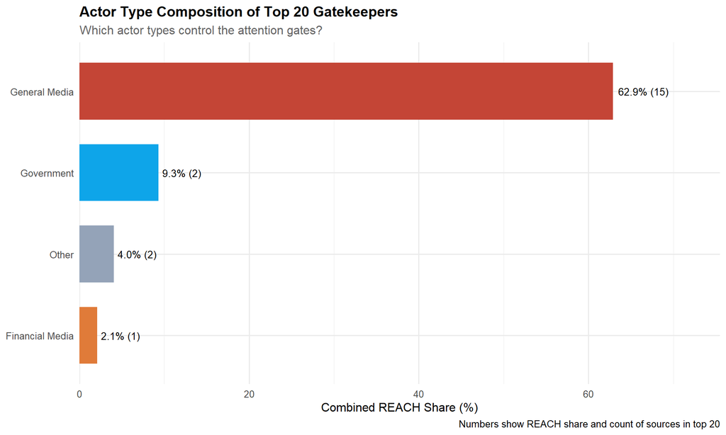

```r
# What actor types dominate the top 20?
top20_actor <- top20[, .(
  Sources = .N,
  Total_REACH = sum(Total_REACH),
  REACH_Share = sum(REACH_Share)
), by = ACTOR_TYPE][order(-REACH_Share)]

ggplot(top20_actor, aes(x = reorder(ACTOR_TYPE, REACH_Share), y = REACH_Share, fill = ACTOR_TYPE)) +
  geom_col(width = 0.7) +
  geom_text(aes(label = sprintf("%.1f%% (%d)", REACH_Share, Sources)), hjust = -0.1, size = 3.5) +
  coord_flip() +
  scale_fill_manual(values = actor_colors) +
  scale_y_continuous(expand = expansion(mult = c(0, 0.2))) +
  labs(
    title = "Actor Type Composition of Top 20 Gatekeepers",
    subtitle = "Which actor types control the attention gates?",
    x = NULL,
    y = "Combined REACH Share (%)",
    caption = "Numbers show REACH share and count of sources in top 20"
  ) +
  theme(legend.position = "none")
```

# 4 Analysis 6.3: Power Law Analysis

Media attention markets often follow power law distributions where a few sources dominate while most have minimal reach. We test whether HNB coverage follows this pattern.

## 4.1 Rank-Size Distribution (Zipf Plot)

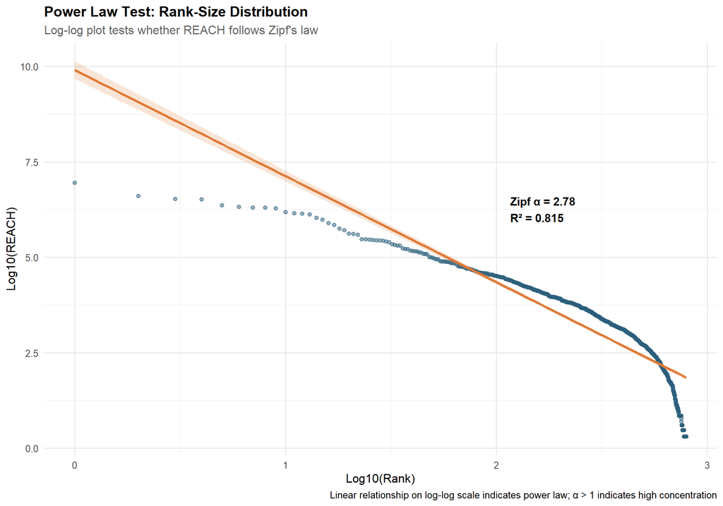

```r
# Log-log plot for power law detection
source_stats[, log_rank := log10(Rank)]
source_stats[, log_reach := log10(Total_REACH + 1)]

# Fit linear model on log-log scale
zipf_model <- lm(log_reach ~ log_rank, data = source_stats[Total_REACH > 0])
zipf_alpha <- -coef(zipf_model)[2]  # Zipf exponent (negative of slope)
zipf_r2 <- summary(zipf_model)$r.squared

ggplot(source_stats[Total_REACH > 0], aes(x = log_rank, y = log_reach)) +
  geom_point(alpha = 0.5, color = "#2c5f7c") +
  geom_smooth(method = "lm", se = TRUE, color = "#e07b39", fill = "#e07b39", alpha = 0.2) +
  annotate("text", x = max(source_stats$log_rank) * 0.7, y = max(source_stats$log_reach) * 0.9,
           label = paste0("Zipf α = ", sprintf("%.2f", zipf_alpha), "\nR² = ", sprintf("%.3f", zipf_r2)),
           hjust = 0, size = 4, fontface = "bold") +
  labs(
    title = "Power Law Test: Rank-Size Distribution",
    subtitle = "Log-log plot tests whether REACH follows Zipf's law",
    x = "Log10(Rank)",
    y = "Log10(REACH)",
    caption = "Linear relationship on log-log scale indicates power law; α > 1 indicates high concentration"
  )
```

## 4.2 Power Law Interpretation

```r
cat("Power Law Analysis Results\n")
```

```
Power Law Analysis Results
```

```r
cat("==========================\n")
cat("Zipf exponent (α):", sprintf("%.2f", zipf_alpha), "\n")
```

```
Zipf exponent (α): 2.78
```

```r
cat("R-squared:", sprintf("%.3f", zipf_r2), "\n")
```

```
R-squared: 0.815
```

```r
cat("\nInterpretation:\n")
```

```
Interpretation:
```

```r
if (zipf_r2 > 0.8) {
  cat("- Strong power law fit (R² > 0.8)\n")
} else if (zipf_r2 > 0.6) {
  cat("- Moderate power law fit (R² 0.6-0.8)\n")
} else {
  cat("- Weak power law fit (R² < 0.6)\n")
}
```

```
- Strong power law fit (R² > 0.8)
```

```r
if (zipf_alpha > 1.5) {
  cat("- Very high concentration (α > 1.5): Winner-take-most dynamics\n")
} else if (zipf_alpha > 1) {
  cat("- High concentration (α > 1): Top sources dominate significantly\n")
} else {
  cat("- Moderate concentration (α ≤ 1): More distributed attention\n")
}
```

```
- Very high concentration (α > 1.5): Winner-take-most dynamics
```

```r
cat("\nImplication for HNB communication:\n")
```

```
Implication for HNB communication:
```

```r
if (zipf_alpha > 1 && zipf_r2 > 0.7) {
  cat("The attention market follows predictable power law dynamics.\n")
  cat("A small number of gatekeepers will consistently dominate reach.\n")
  cat("Strategic relationships with top sources are critical.\n")
}
```

```
The attention market follows predictable power law dynamics.
A small number of gatekeepers will consistently dominate reach.
Strategic relationships with top sources are critical.
```

# 5 Analysis 6.4: Period Comparison

## 5.1 Concentration Changes: ERM II vs Euro Era

```r
# Calculate concentration metrics by period
period_concentration <- hnb[, {
  source_period <- .SD[, .(Total_REACH = sum(REACH, na.rm = TRUE)), by = FROM][order(-Total_REACH)]
  source_period[, REACH_Share := Total_REACH / sum(Total_REACH) * 100]

  list(
    Sources = uniqueN(FROM),
    Gini = ineq(source_period$Total_REACH, type = "Gini"),
    HHI = sum(source_period$REACH_Share^2),
    CR4 = sum(source_period$REACH_Share[1:min(4, .N)]),
    CR10 = sum(source_period$REACH_Share[1:min(10, .N)]),
    Top_Source = source_period$FROM[1],
    Top_Source_Share = source_period$REACH_Share[1]
  )
}, by = period]

period_concentration %>%
  mutate(
    Sources = format(Sources, big.mark = ","),
    Gini = sprintf("%.3f", Gini),
    HHI = sprintf("%.0f", HHI),
    CR4 = sprintf("%.1f%%", CR4),
    CR10 = sprintf("%.1f%%", CR10),
    Top_Source_Share = sprintf("%.1f%%", Top_Source_Share)
  ) %>%
  kable(col.names = c("Period", "Sources", "Gini", "HHI", "CR4", "CR10",
                      "Top Source", "Top Source %")) %>%
  kable_styling(bootstrap_options = c("striped", "hover"), full_width = FALSE)
```

| Period | Sources | Gini | HHI | CR4 | CR10 | Top Source | Top Source % |
| --- | --- | --- | --- | --- | --- | --- | --- |
| ERM II | 749 | 0.946 | 559 | 34.7% | 59.0% | index.hr | 17.4% |
| Euro Era | 470 | 0.940 | 745 | 49.0% | 70.6% | index.hr | 16.8% |

## 5.2 Concentration Trend Visualization

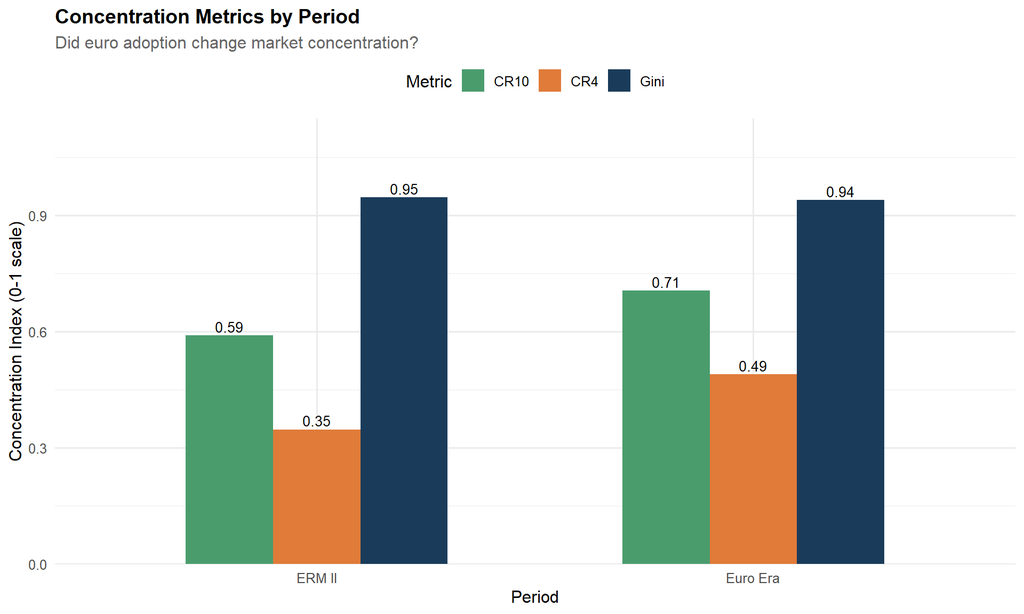

```r
period_conc_long <- period_concentration %>%
  select(period, Gini, CR4, CR10) %>%
  mutate(CR4 = CR4 / 100, CR10 = CR10 / 100) %>%  # Normalize to 0-1 scale
  pivot_longer(cols = -period, names_to = "Metric", values_to = "Value")

ggplot(period_conc_long, aes(x = period, y = Value, fill = Metric)) +
  geom_col(position = "dodge", width = 0.6) +
  geom_text(aes(label = sprintf("%.2f", Value)),
            position = position_dodge(width = 0.6), vjust = -0.3, size = 3.5) +
  scale_fill_manual(values = c("Gini" = "#1a3c5a", "CR4" = "#e07b39", "CR10" = "#4a9c6d")) +
  scale_y_continuous(expand = expansion(mult = c(0, 0.15)), limits = c(0, 1)) +
  labs(
    title = "Concentration Metrics by Period",
    subtitle = "Did euro adoption change market concentration?",
    x = "Period",
    y = "Concentration Index (0-1 scale)",
    fill = "Metric"
  ) +
  theme(legend.position = "top")
```

# 6 Analysis 6.5: Gatekeeper Stability

## 6.1 Do the Same Sources Dominate Across Periods?

```r
# Get top 20 sources in each period
top_erm2 <- hnb[period == "ERM II", .(Total_REACH = sum(REACH, na.rm = TRUE)), by = FROM][order(-Total_REACH)][1:20]
top_euro <- hnb[period == "Euro Era", .(Total_REACH = sum(REACH, na.rm = TRUE)), by = FROM][order(-Total_REACH)][1:20]

# Calculate overlap
overlap_sources <- intersect(top_erm2$FROM, top_euro$FROM)
overlap_pct <- length(overlap_sources) / 20 * 100

# Rank correlation
both_periods <- merge(
  top_erm2[, .(FROM, REACH_ERM2 = Total_REACH, Rank_ERM2 = .I)],
  top_euro[, .(FROM, REACH_Euro = Total_REACH, Rank_Euro = .I)],
  by = "FROM", all = TRUE
)

# Spearman correlation for overlapping sources
overlap_data <- both_periods[!is.na(Rank_ERM2) & !is.na(Rank_Euro)]
if (nrow(overlap_data) >= 3) {
  rank_cor <- cor(overlap_data$Rank_ERM2, overlap_data$Rank_Euro, method = "spearman")
} else {
  rank_cor <- NA
}

cat("Gatekeeper Stability Analysis\n")
```

```
Gatekeeper Stability Analysis
```

```r
cat("=============================\n")
cat("Top 20 overlap between periods:", length(overlap_sources), "sources\n")
```

```
Top 20 overlap between periods: 14 sources
```

```r
cat("Overlap percentage:", sprintf("%.0f%%", overlap_pct), "\n")
```

```
Overlap percentage: 70%
```

```r
cat("Rank correlation (Spearman):", ifelse(is.na(rank_cor), "N/A", sprintf("%.2f", rank_cor)), "\n")
```

```
Rank correlation (Spearman): 0.91
```

```r
cat("\nOverlapping gatekeepers:\n")
```

```
Overlapping gatekeepers:
```

```r
for (s in overlap_sources) {
  cat("  -", s, "\n")
}
```

```
  - index.hr
  - jutarnji.hr
  - dnevno.hr
  - gov.hr
  - telegram.hr
  - 24sata.hr
  - vecernji.hr
  - slobodnadalmacija.hr
  - tportal.hr
  - dnevnik.hr
  - poslovni.hr
  - priznajem.hr
  - novilist.hr
  - Ivan Lovrinović
```

## 6.2 Gatekeeper Movement Visualization

```r
# Prepare data for bump chart style visualization
movement_data <- merge(
  top_erm2[, .(FROM, Rank_ERM2 = .I)],
  top_euro[, .(FROM, Rank_Euro = .I)],
  by = "FROM", all = TRUE
)
movement_data[is.na(Rank_ERM2), Rank_ERM2 := 25]  # New entrants
movement_data[is.na(Rank_Euro), Rank_Euro := 25]   # Dropped out

movement_data[, Movement := Rank_ERM2 - Rank_Euro]  # Positive = improved
movement_data[, Status := fcase(
  Rank_ERM2 == 25, "New in Euro Era",
  Rank_Euro == 25, "Dropped from Top 20",
  abs(Movement) <= 3, "Stable",
  Movement > 0, "Improved",
  Movement < 0, "Declined"
)]

# Show sources with biggest movements
movement_data[order(-abs(Movement))][1:15] %>%
  mutate(
    Rank_ERM2 = ifelse(Rank_ERM2 == 25, "Not in Top 20", as.character(Rank_ERM2)),
    Rank_Euro = ifelse(Rank_Euro == 25, "Not in Top 20", as.character(Rank_Euro)),
    Movement = sprintf("%+d", Movement)
  ) %>%
  kable(col.names = c("Source", "Rank (ERM II)", "Rank (Euro Era)", "Movement", "Status"),
        caption = "Gatekeeper Position Changes") %>%
  kable_styling(bootstrap_options = c("striped", "hover"), full_width = FALSE)
```

Gatekeeper Position Changes

| Source | Rank (ERM II) | Rank (Euro Era) | Movement | Status |
| --- | --- | --- | --- | --- |
| n1info.com | 3 | Not in Top 20 | -22 | Dropped from Top 20 |
| zagorje.com | 9 | Not in Top 20 | -16 | Dropped from Top 20 |
| dalmatinskiportal.hr | 11 | Not in Top 20 | -14 | Dropped from Top 20 |
| Nikola Grmoja | Not in Top 20 | 12 | +13 | New in Euro Era |
| n1info.hr | Not in Top 20 | 14 | +11 | New in Euro Era |
| net.hr | Not in Top 20 | 15 | +10 | New in Euro Era |
| glasistre.hr | Not in Top 20 | 16 | +9 | New in Euro Era |
| rtl.hr | 16 | Not in Top 20 | -9 | Dropped from Top 20 |
| DNEVNIK.hr | Not in Top 20 | 17 | +8 | New in Euro Era |
| nacional.hr | 18 | Not in Top 20 | -7 | Dropped from Top 20 |
| novilist.hr | 17 | 10 | +7 | Improved |
| Hrvatska narodna banka | Not in Top 20 | 19 | +6 | New in Euro Era |
| hnb.hr | 20 | Not in Top 20 | -5 | Dropped from Top 20 |
| priznajem.hr | 15 | 20 | -5 | Declined |
| slobodnadalmacija.hr | 10 | 5 | +5 | Improved |

# 7 Analysis 6.6: Fragility Assessment

## 7.1 What If Top Gatekeepers Shift Coverage?

This analysis quantifies the fragility of the attention ecosystem. If top sources changed their HNB coverage behavior, how much attention would be affected?

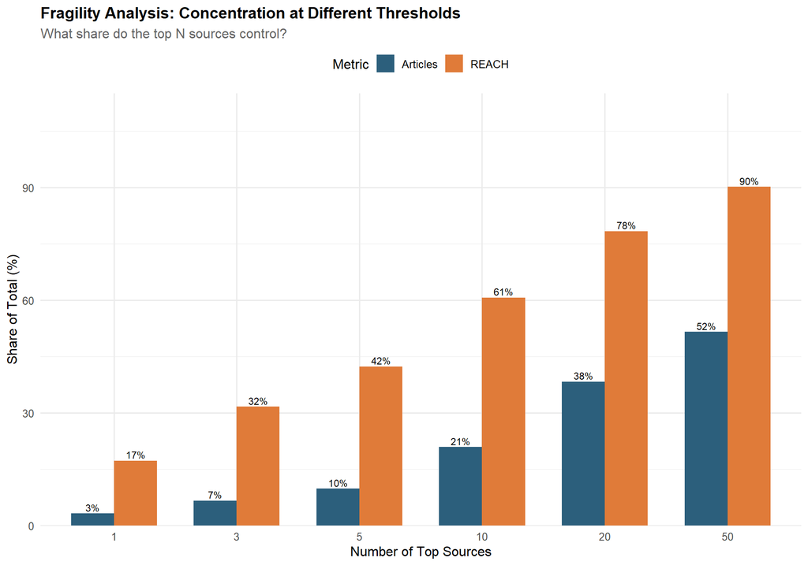

```r
# Calculate concentration at different thresholds
fragility_data <- data.table(
  Top_N = c(1, 3, 5, 10, 20, 50),
  REACH_Share = sapply(c(1, 3, 5, 10, 20, 50), function(n) {
    sum(source_stats$REACH_Share[1:min(n, nrow(source_stats))])
  }),
  Article_Share = sapply(c(1, 3, 5, 10, 20, 50), function(n) {
    sum(source_stats$Article_Share[1:min(n, nrow(source_stats))])
  })
)

fragility_data[, Sources_Pct := Top_N / n_sources * 100]

fragility_long <- fragility_data %>%
  pivot_longer(cols = c(REACH_Share, Article_Share),
               names_to = "Metric", values_to = "Share") %>%
  mutate(Metric = ifelse(Metric == "REACH_Share", "REACH", "Articles"))

ggplot(fragility_long, aes(x = factor(Top_N), y = Share, fill = Metric)) +
  geom_col(position = "dodge", width = 0.7) +
  geom_text(aes(label = sprintf("%.0f%%", Share)),
            position = position_dodge(width = 0.7), vjust = -0.3, size = 3) +
  scale_fill_manual(values = c("REACH" = "#e07b39", "Articles" = "#2c5f7c")) +
  scale_y_continuous(expand = expansion(mult = c(0, 0.15)), limits = c(0, 100)) +
  labs(
    title = "Fragility Analysis: Concentration at Different Thresholds",
    subtitle = "What share do the top N sources control?",
    x = "Number of Top Sources",
    y = "Share of Total (%)",
    fill = "Metric"
  ) +
  theme(legend.position = "top")
```

## 7.2 Fragility Summary Table

```r
fragility_data %>%
  mutate(
    `% of All Sources` = sprintf("%.1f%%", Sources_Pct),
    `REACH Share` = sprintf("%.1f%%", REACH_Share),
    `Article Share` = sprintf("%.1f%%", Article_Share),
    `Concentration Ratio` = sprintf("%.1fx", REACH_Share / Article_Share)
  ) %>%
  select(Top_N, `% of All Sources`, `Article Share`, `REACH Share`, `Concentration Ratio`) %>%
  kable(col.names = c("Top N Sources", "% of All Sources", "Article Share",
                      "REACH Share", "REACH/Article Ratio"),
        caption = "How concentrated is attention at different thresholds?") %>%
  kable_styling(bootstrap_options = c("striped", "hover"), full_width = FALSE)
```

How concentrated is attention at different thresholds?

| Top N Sources | % of All Sources | Article Share | REACH Share | REACH/Article Ratio |
| --- | --- | --- | --- | --- |
| 1 | 0.1% | 3.3% | 17.3% | 5.3x |
| 3 | 0.3% | 6.7% | 31.6% | 4.7x |
| 5 | 0.6% | 9.8% | 42.3% | 4.3x |
| 10 | 1.1% | 20.9% | 60.7% | 2.9x |
| 20 | 2.2% | 38.3% | 78.4% | 2.0x |
| 50 | 5.6% | 51.6% | 90.2% | 1.7x |

## 7.3 HNB Position in Market Structure

```r
# Where does HNB Official rank?
hnb_rank <- source_stats[ACTOR_TYPE == "HNB Official", Rank][1]
hnb_reach_share <- source_stats[ACTOR_TYPE == "HNB Official", REACH_Share][1]
hnb_article_share <- source_stats[ACTOR_TYPE == "HNB Official", Article_Share][1]

# How many non-institutional sources rank above HNB?
sources_above_hnb <- source_stats[Rank < hnb_rank]
media_above_hnb <- sources_above_hnb[ACTOR_TYPE %in% c("Financial Media", "General Media")]

cat("HNB Official Position in Market Structure\n")
```

```
HNB Official Position in Market Structure
```

```r
cat("==========================================\n")
cat("HNB Official rank:", hnb_rank, "of", n_sources, "sources\n")
```

```
HNB Official rank: 22 of 894 sources
```

```r
cat("HNB REACH share:", sprintf("%.2f%%", hnb_reach_share), "\n")
```

```
HNB REACH share: 0.74%
```

```r
cat("HNB Article share:", sprintf("%.2f%%", hnb_article_share), "\n")
```

```
HNB Article share: 1.61%
```

```r
cat("\nSources ranking above HNB Official:", nrow(sources_above_hnb), "\n")
```

```
Sources ranking above HNB Official: 21
```

```r
cat("  - Media sources above HNB:", nrow(media_above_hnb), "\n")
```

```
  - Media sources above HNB: 17
```

```r
cat("\nThese", nrow(sources_above_hnb), "sources capture",
    sprintf("%.1f%%", sum(sources_above_hnb$REACH_Share)), "of total REACH\n")
```

```
These 21 sources capture 79.1% of total REACH
```

# 8 Summary and Key Findings

## 8.1 Market Structure Summary

```r
tibble(
  Finding = c(
    "Total sources in ecosystem",
    "Gini coefficient (REACH)",
    "HHI classification",
    "Top source REACH share",
    "Top 4 sources REACH share",
    "Top 10 sources REACH share",
    "Sources needed for 50% REACH",
    "Sources needed for 80% REACH",
    "Power law exponent (α)",
    "Gatekeeper stability (overlap %)",
    "HNB Official rank",
    "HNB Official REACH share"
  ),
  Value = c(
    format(n_sources, big.mark = ","),
    sprintf("%.3f", gini_reach),
    hhi_class,
    sprintf("%.1f%%", cr1_reach),
    sprintf("%.1f%%", cr4_reach),
    sprintf("%.1f%%", cr10_reach),
    as.character(reach_50),
    as.character(reach_80),
    sprintf("%.2f", zipf_alpha),
    sprintf("%.0f%%", overlap_pct),
    as.character(hnb_rank),
    sprintf("%.2f%%", hnb_reach_share)
  )
) %>%
  kable(col.names = c("Finding", "Value")) %>%
  kable_styling(bootstrap_options = c("striped", "hover"), full_width = FALSE)
```

[output not shown]

## 8.2 Implications for HNB Communication Strategy

Based on the concentration analysis:

**1. Gatekeeper Dependency**

- Strategic relationships with top 4 sources are critical
- Editorial decisions at these outlets disproportionately affect HNB message reach
- Diversification of media relationships reduces single-point-of-failure risk

**2. Fragility Risk**

The Zipf exponent of 2.78 indicates:

- Winner-take-most dynamics where top sources will consistently dominate
- Marginal sources have minimal impact regardless of content quality
- Resources should focus on high-reach channels rather than broad distribution

**4. Structural Position**

HNB Official ranks #22 with 0.74% REACH share, meaning:

- 21 sources capture more attention than official HNB communication
- Direct communication competes with 17 media sources for visibility
- The attention gap (Map 5) is structurally embedded in market concentration

# 9 Appendix: Methodological Notes

## 9.1 Concentration Metrics

**Gini Coefficient:** Measures inequality on a 0-1 scale. For n sources with shares $x_i$:
$$G = \frac{\sum_{i=1}^{n}\sum_{j=1}^{n}|x_i - x_j|}{2n\sum_{i=1}^{n}x_i}$$

**HHI (Herfindahl-Hirschman Index):** Sum of squared percentage market shares:
$$HHI = \sum_{i=1}^{n}s_i^2$$

Where $s_i$ is the percentage market share of source $i$. Range: 0 to 10,000.

**Concentration Ratios (CR):** Sum of market shares for top N sources.

**Zipf Exponent:** From regression of log(REACH) on log(Rank): $\log(REACH) = \alpha - \beta \log(Rank)$

## 9.2 DOJ/FTC Guidelines (adapted)

- HHI < 1,500: Unconcentrated market
- HHI 1,500-2,500: Moderately concentrated
- HHI > 2,500: Highly concentrated